# fred

Peter Kowalchuk

December 5, 2018

```r
library("rvest")
library(tidyr)
require(mongolite)
library(dplyr)
```

```r
library(ggplot2)

library(FredR)
library(pipeR)
library(dplyr)
library(tidyr)
```

## Economy Health Classifier

For our Economy Health Classifier we start by procuring a monthly economy indicator from the FRED site.

```r
api.key = "4844eb6986119824760163e60bddd945"
fred<-FredR(api.key)

gdp.series <- fred$series.search("GDP")
#gdp.series
```

```r
pay <- fred$series.observations(series_id = 'PAYEMS')
head(pay,n=100)
```

```
##      realtime_start realtime_end       date value
##   1:     2018-12-07   2018-12-07 1939-01-01 29923
##   2:     2018-12-07   2018-12-07 1939-02-01 30101
##   3:     2018-12-07   2018-12-07 1939-03-01 30280
##   4:     2018-12-07   2018-12-07 1939-04-01 30094
##   5:     2018-12-07   2018-12-07 1939-05-01 30300
##   6:     2018-12-07   2018-12-07 1939-06-01 30502
##   7:     2018-12-07   2018-12-07 1939-07-01 30419
##   8:     2018-12-07   2018-12-07 1939-08-01 30663
##   9:     2018-12-07   2018-12-07 1939-09-01 31032
##  10:     2018-12-07   2018-12-07 1939-10-01 31408
##  11:     2018-12-07   2018-12-07 1939-11-01 31469
##  12:     2018-12-07   2018-12-07 1939-12-01 31539
##  13:     2018-12-07   2018-12-07 1940-01-01 31603
##  14:     2018-12-07   2018-12-07 1940-02-01 31715
```

[output cut: 87 more lines]

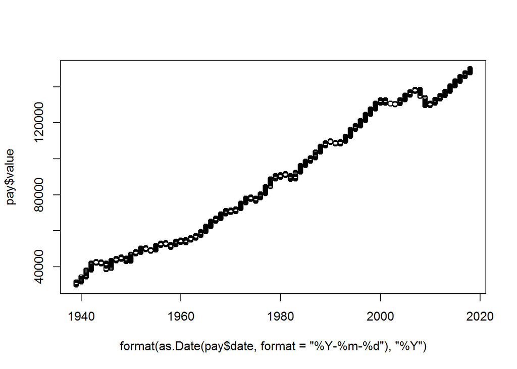

```r
plot(format(as.Date(pay$date,format="%Y-%m-%d"),"%Y"),pay$value)
```

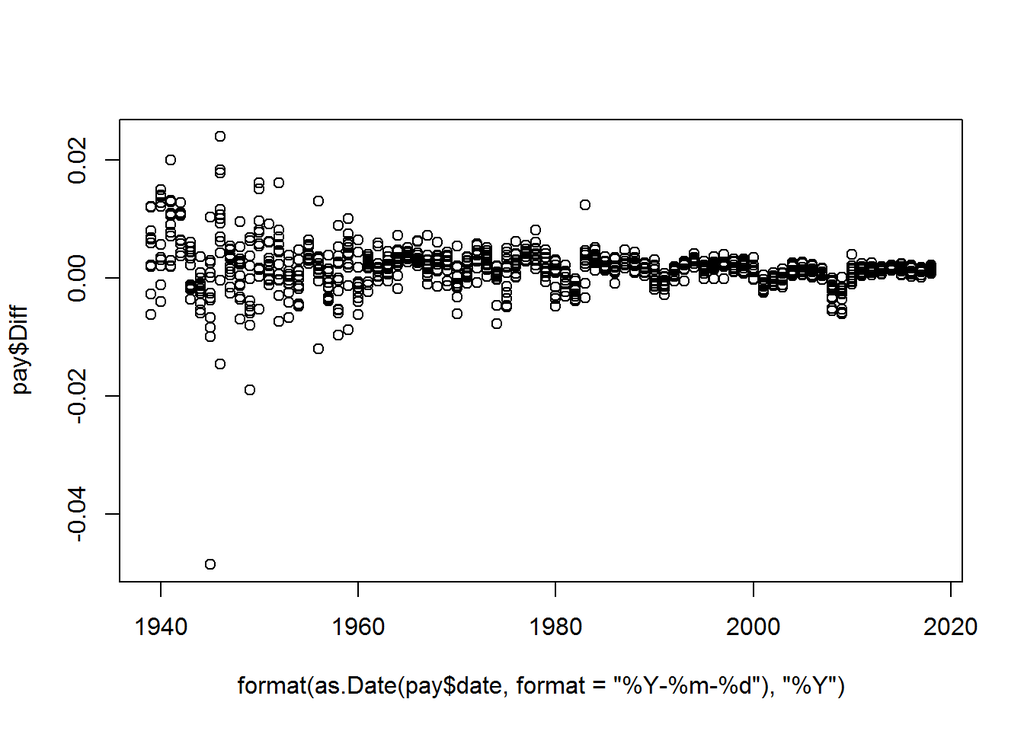

```r
pay$value<-as.numeric(pay$value)
pay <- pay %>% mutate(Diff = (value - lag(value))/lag(value))
plot(format(as.Date(pay$date,format="%Y-%m-%d"),"%Y"),pay$Diff)
```

Visual inspection of the data reveals how payrolls made wide positive and negative swings during the 40’s and 50’s. After 1960 the data shows much clearer with possible patterns emerging. Our analysis will concentrate on data starting from 1978, which is the period for which we have congress party composition data.

To build our classifier we need to establish thresholds for good, medium and poor economy. The idea is that high employment growth represents a good economy, and low employment growth is a bad economy. We look at a summary of our data to determine what would be good thresholds to use.

```r
pay<-na.omit(pay)
summary(pay$Diff)
```

```
##       Min.    1st Qu.     Median       Mean    3rd Qu.       Max.
## -0.0486075  0.0002276  0.0017003  0.0016911  0.0030992  0.0239994
```

We classify our data as: - Poor economy: payroll growth below 1st quartile - Medium economy: payroll growth between 1st and 3rd quartile - Good economy: payroll growth above 3rd quartile

```r
poor<-summary(pay$Diff)[2]
good<-summary(pay$Diff)[5]
pay$Health <- ifelse(pay$Diff < poor, "Bad", "Medium")
pay$Health <- ifelse(pay$Diff > good, "Good", pay$Health)
```

Now that we have our output classification ready, our classifier will use as input features the number of congressional seats in Congress per party for both chambers. We build a table with our classification and the six input features (Democratic, Republican and Other number of seats for both the House and Senate).

## No need for this after paste

## Electoral Data

For this analysis we will need data showing the number of congress and senate seats occupied by both parties. This data was scrapped from The University of Wisconsin’s web page.

```r
url <- "https://web.education.wisc.edu/nwhillman/index.php/2017/02/01/party-control-in-congress-and-state-legislatures/"
congress_by_party <- url %>%
  read_html() %>%
  html_table()
# this is wide format .
congress_by_party <- congress_by_party[[1]]
head(congress_by_party,n=100)
```

```
##      X1     X2     X3     X4    X5    X6    X7                 X8
## 1    NA Senate Senate Senate House House House State Legislatures
## 2    NA    Dem    Rep    Oth   Dem   Rep   Oth                Dem
## 3  1978     58     41      1   277   158     0                 31
## 4  1980     46     53      1   242   192     1                 28
## 5  1982     46     54      0   269   166     0                 34
## 6  1984     47     53      0   253   182     0                 28
## 7  1986     55     45      0   258   177     0                 27
## 8  1988     55     45      0   260   175     0                 29
## 9  1990     56     44      0   267   167     1                 29
## 10 1992     57     43      0   258   176     1                 26
## 11 1994     48     52      0   204   230     1                 22
## 12 1996     45     55      0   207   226     2                 20
## 13 1998     45     55      0   211   223     1                 20
## 14 2000     50     50      0   212   221     2                 16
```

[output cut: 31 more lines]

## Electoral Dataset

For our analysis, electoral data is taken into a long table format from its original wide table format in the University’s website.

```r
# conver to long format. year, party, chamber, seats
congress_by_party  <- congress_by_party %>% select(1:7)

names(congress_by_party) <- c('date',
                              paste(congress_by_party[1,2], congress_by_party[2,2]),
                              paste(congress_by_party[1,3], congress_by_party[2,3]),
                              paste(congress_by_party[1,4], congress_by_party[2,4]),
                              paste(congress_by_party[1,5], congress_by_party[2,5]),
                              paste(congress_by_party[1,6], congress_by_party[2,6]),
                              paste(congress_by_party[1,7], congress_by_party[2,7])
                              )
congress_by_party <- congress_by_party %>%
                    mutate(Senate =ifelse(congress_by_party$`Senate Dem` > congress_by_party$`Senate Rep`, "Dem", ifelse(congress_by_party$`Senate Dem` == congress_by_party$`Senate Rep`, 'Hung','Rep')))

congress_by_party <- congress_by_party %>%
                    mutate(House =ifelse(congress_by_party$`House Dem` > congress_by_party$`House Rep`, "Dem", ifelse(congress_by_party$`House Dem` == congress_by_party$`House Rep`, 'Hung','Rep')))

congress_by_party<- congress_by_party[c(3:22),] %>% arrange(desc(date))

congress_by_party$date <- as.numeric(congress_by_party$date)

#Fill int the data for the year between elections
congress_by_party_between_years <- congress_by_party

congress_by_party_between_years$date <-congress_by_party_between_years$date+1

congress <- rbind(congress_by_party, congress_by_party_between_years)

congress<- congress %>% arrange(desc(date))
```

## End

Do be able to join the payroll with the congressional dataset, we need to first fill in monthly rows in the congressional table.

```r
monthy_congress<-congress %>% slice(rep(1:n(), each = 12))
colnames(monthy_congress)[1]<-"Year"
pay$Year<-substring(pay$date,1,4)
pay$Year<-as.numeric(pay$Year)
health_congress<-inner_join(pay,monthy_congress) %>% select(6:13) %>% subset(select=-Year)
```

The resulting dataset from these transformations has the classifier’s 6 input features, and the three level economy healt output.

With our data ready we can now select a scikit-learn classifier to use. We will use the MLPClassifier in Scikit-Learn, which implements a neural network classifier. We build the required input for the trassifier by transforming the data in our table. The classifier requires a X matrix with samplesxfeatures, and a y vector with samples.

```r
library(reticulate)

X<-subset(health_congress,select = -Health)
X<-data.matrix(X)

y<-health_congress$Health
y <- ifelse(y == "Bad", 0, y)
y <- ifelse(y == "Medium", 1, y)
y <- ifelse(y == "Good", 2, y)
```

```python
import numpy as np
from sklearn.neural_network import MLPClassifier
from sklearn.model_selection import train_test_split
from sklearn.metrics import confusion_matrix
X=np.array(r.X)
X=X.astype(np.float)
y=list(map(int,r.y))
X_train, X_test, y_train, y_test = train_test_split(X, y, test_size=0.3)
clf = MLPClassifier(solver='lbfgs', alpha=1e-5,hidden_layer_sizes=(415, 218), random_state=1)
clf.fit(X_train, y_train)
y_pred = clf.predict(X_test)
cnf_matrix = confusion_matrix(y_test, y_pred)
print(cnf_matrix)
```

```
## [[   0  344   52]
##  [   0 1152   14]
##  [   0  147   19]]
```

```python
res=clf.predict([[47, 51, 2, 197, 236, 0], [45, 53, 2, 235, 199, 0]])
```

```r
py$cnf_matrix
```

```
##      [,1] [,2] [,3]
## [1,]    0  344   52
## [2,]    0 1152   14
## [3,]    0  147   19
```

```r
cnf_matrix<-as.data.frame(as.table(py$cnf_matrix))
colnames(cnf_matrix)<-c("Real","Prediction","Count")
cnf_matrix
```

```
##   Real Prediction Count
## 1    A          A     0
## 2    B          A     0
## 3    C          A     0
## 4    A          B   344
## 5    B          B  1152
## 6    C          B   147
## 7    A          C    52
## 8    B          C    14
## 9    C          C    19
```

```r
library(reshape2)
```

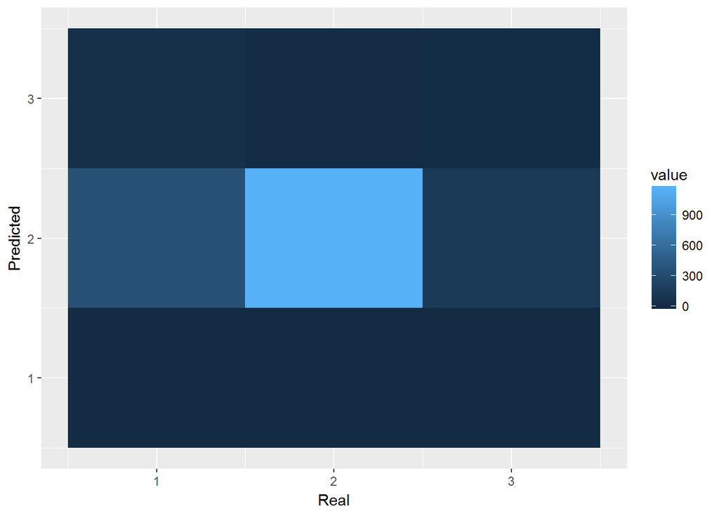

```r
melted_matrix <- melt(py$cnf_matrix)
library(ggplot2)
ggplot(data = melted_matrix, aes(x=Var1, y=Var2, fill=value)) +
  geom_tile() + labs(x = "Real", y = "Predicted")
```

```r
res<-py$res
res <- ifelse(res == 0,"Bad", res)
res <- ifelse(res == 1,"Medium", res)
res <- ifelse(res == 2,"Good", res)
res
```

```
## [1] "Medium" "Medium"
```